# Introduction to single-cell RNA-seq analysis

Clustering and Marker Genes Exercise

Ashley Sawle

April 2024

# Preamble

During the live session we clustered cells from 7 of the Caron dataset samples, but only using 500 cells per sample. We used the Walktrap algorithm with a small number of different values for *k*. In this exercise you will run the clustering again on these samples, but this time using all the cells. Additionally, you will run a larger range of clusterings using `clusterSweep`.

Once you have the clustering results you can assess them using the various metrics described in the main course materials and an additional metric: “Within-cluster sum of squares”. You can then select a few clusterings for further investigation by plotting them on a TSNE and comparing them to the expression of known cell marker genes.

Finally you will select one clustering that you think best represents the biology and identify marker genes that drive the separation between the clusters.

For this exercise the OSCA books [“Basic”](http://bioconductor.org/books/release/OSCA.basic/clustering.html#clustering-graph) and [“Advanced”](http://bioconductor.org/books/3.15/OSCA.advanced/clustering-redux.html) chapters on clustering will be extremely useful.

First `rsync` the **Course_Materials** directory into your working directory using:

```bash
rsync -vrptg /scratcha/bioinformatics/Course_Materials .
```

# 1. Run `clusterSweep` to generate a range of different clustering

In the **scripts** directory you will find a batch script called *ClusterSweep.R*. You will need to modify this script before running. The sections you need to modify/add code are marked **<>**. You can do the modifications in RStudio if you wish, but will need to submit the script from the command line.

This batch script uses `Rscript` rather than `bash` meaning we can just write R code and send it directly to the cluster. To achieve this the first line is:

```
#!/usr/bin/env Rscript
```

rather than

```
#!/bin/bash
```

First, on line 18, you will need to set the working directory to your **Course_Materials** directory.

The script will load the data set - 7 Caron samples that have been QC’d, filtered, normalized and batch corrected - from the RDS file *Caron_batch_corrected.all_cells.rds*.

You should then add code to run `clusterSweep` on line 25. I suggest using Leiden, Louvain, and one other algorithm. You can find the other available algorithms in the OSCA book basic chapter about clustering under the section [Adjusting the parameters](https://bioconductor.org/books/3.18/OSCA.basic/clustering.html#adjusting-the-parameters). You should also test a range of different values of *k*. `clusterSweep` will run all possible combinations.

To run the *ClusterSweep.R* using the same R as we are using in the RStudio server we need to call the script using a second bash script which runs the Singularity image that contains the RStudio server. This script is called *RunClusterSweepRscript.sh*. You don’t need to change anything in the script, it simply starts the Singularity image and runs the RScript using it.

Once `clusterSweep` has run, the script will write an RDS object called *Robjects/clusterSweep.out.rds* containing the output of `clusterSweep`. It will also add all the resulting clusters to the SCE object and write the SCE object to an RDS object called *Robjects/clusterSweep.sce.rds*.

We also want to generate a data.frame containing the cluster behaviour metrics. The script already contains the code for adding the numbers of clusters and the mean silhouette width - as demonstrated in the live session. At line 48 you should also add some code to generate the sum of the Within-cluster Mean Sum of Squares - you can find out about this metric in the OSCA book’s “Advanced” clustering chapter in section 2.5.4 of [Quantifying clustering behavior](http://bioconductor.org/books/release/OSCA.advanced/clustering-redux.html#quantifying-clustering-behavior) and how to apply it to `clusterSweep` results under the [Clustering parameter sweeps section](http://bioconductor.org/books/release/OSCA.advanced/clustering-redux.html#clustering-parameter-sweeps).

Finally, the script will write out these metrics to a tab separated table called *Robjects/clusterSweep.metrics_df.tsv*.

Once you have modified the code in the script you can submit this to the cluster from the command line. To run the scripts just use the following command from within the **Course_Materials** directory:

```
sbatch scripts/RunClusterSweepRscript.sh
```

When the script has run, check the error log file to make sure that the script ran through without error and check that all of the output files have been generated. You should have three new files:

- *R_objects/clusterSweep.out.rds*
- *R_objects/clusterSweep.metrics_df.tsv*
- *R_objects/clusterSweep.sce.rds*

# 2. Assess the clusterings

You are now going to assess the clusterings and select one to proceed with for the downstream analyses. You will do this in R and this is a good time to start to use R markdowns instead of R scripts. If you are not familiar with R markdowns, they allow us to combine plain text with chunks of R code, in this way we can write a report that can be rendered to html or pdf. One of the main advantages here is that any plots or tables generated are displayed in-line with the code in RStudio, which is much more convenient than plotting to the “Plots” window or writing them to a file. In the scripts directory there is a file *Clustering_and_Marker_Genes.Rmd*. It already contains a brief introduction, which you can modify to record your `clusterSweep` parameters, and couple of chunks of R code to get you started.

First load the metrics data.frame generated by the script and use this to assess the behaviour of the different clusterings. Based on this select a few that you think might be worth further investgation.

Plot each clustering on the TSNE or UMAP plots to get an initial impression, you may at this stage want to narrow down the number of clusterings you are interested or go back and pick some different ones.

Use per-cell silhouette scores, modularity, and within-cluster mean sum of squares (or any other methods in the OSCA book you wish to try) to assess the cluster behaviour and perhaps plot some of the immune cell marker genes to see how well these compare to your clusters.

Suitable markers might include:

- *HBA1* and *HBA2* - expressed in red blood cells (erythrocytes)
- *CST3* - specific to monocytes
- *CD3E* and *CD3D* - specific to T cells
- *NKG7* - specific to natural killer (NK) T cells
- *CD79A* and *CD24* - specific to B cells
- *MS4A1* (CD20) - a clinically-important antigen used as a target to treat B cell-related diseases, such as leukemia. Cells with this antigen are referred to as CD20+ B cells.

Finally, choose one clustering to use for marker gene identification.

# 3. Marker gene selection

Run marker gene selection on your final clustering as described in the materials. You may additionally want to refer the OSCA book for further information.

Q. Can you identify the cell population or populations contained in the group of cells circled in the figure below based on the marker genes for the relevant cluster or clusters?

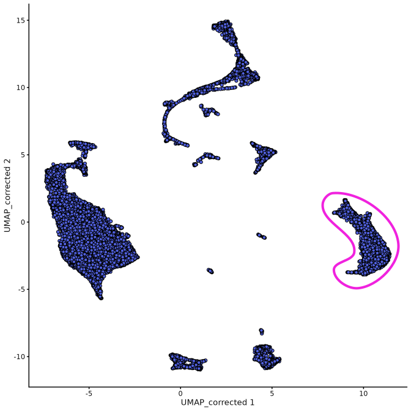